# Question 1

## The following code uses the arrange and count functions to display the count of breweries per state. GGPlot2 is then used to plot the data in a visual representation.

```r
#Chad's Code
colnames(Breweries)[1] <- "Brewery_id"
StateCount = as.data.frame(table(Breweries$State))
colnames(StateCount) <- c("State", "Count")
StateCount <- StateCount %>% arrange(Count)
StateCount
```

```
##    State Count
## 1     DC     1
## 2     ND     1
## 3     SD     1
## 4     WV     1
## 5     AR     2
## 6     DE     2
## 7     MS     2
## 8     NV     2
## 9     AL     3
## 10    KS     3
## 11    NH     3
## 12    NJ     3
## 13    TN     3
## 14    HI     4
```

[output cut: 37 more lines]

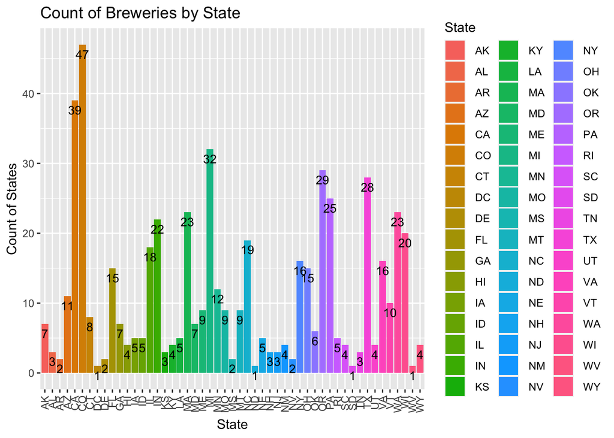

```r
#Brittany's Code
Count_Of_Breweries_By_State = count(Breweries, State)
ggplot_Breweries_By_State = ggplot(data=Count_Of_Breweries_By_State, aes(x=State,y=n,fill=State)) + geom_bar(stat="identity") + theme(axis.text.x=element_text(angle = 90,vjust = 0.5, hjust = 1)) + labs(title="Count of Breweries by State",x= "State",y="Count of States") + geom_text(aes(label=n),vjust=1.6,size=3.5)
ggplot_Breweries_By_State
```

From the plot, we can observe that Colorado California, and Michigan have the highest amount of breweries where as DC, South Dakota, West Verginia, and North Dakota have the least amount at 1 brewery.

# Question 2

## The following code merges the data sets together.

```r
# Chad's Code
table(Beers$IBU, useNA = "always")
```

```
##
##    4    5    6    7    8    9   10   11   12   13   14   15   16   17   18   19
##    3    5    3    7    9   13   18   15   16   12    9   40   24   25   46   11
##   20   21   22   23   24   25   26   27   28   29   30   31   32   33   34   35
##   82   22   35   26   23   45   15   20   25   11   53    9   15   13   12   60
##   36   37   38   39   40   41   42   43   44   45   46   47   48   49   50   51
##   15   12    8    2   41    3   25    7   12   39    6    9    8    5   23    4
##   52   53   54   55   57   58   60   61   62   63   64   65   66   67   68   69
##    9    4    4   31    2    4   44    5    7    1    7   54    5    3   10   13
##   70   71   72   73   74   75   76   77   78   80   81   82   83   85   86   87
##   48    3    8    2    5   31    2    5    1   21    1    5    3   30    4    2
##   88   89   90   91   92   93   94   95   97   98   99  100  101  103  104  105
##    3    1   12    1    3    4    5    3    1    4    4   23    1    3    2    1
##  108  110  111  113  115  118  120  126  130  135  138 <NA>
##    1    3    1    1    5    1    3    1    1    1    1 1005
```

```r
AllData = merge(Beers, Breweries, by = "Brewery_id")
colnames(AllData)[2] <- "Beer_Name"
colnames(AllData)[8] <- "Brewery_Name"

#Brittany's Code
BB_Merged = merge(Beers,Breweries,by.x = "Brewery_id",by.y="Brewery_id")
```

# Question 3

## The following code uses the na.omit function to detect and remove missing values.

```r
#Chad's Code
table(is.na(AllData))
```

```
##
## FALSE  TRUE
## 23033  1067
```

```r
CleanData <- AllData %>% filter(!is.na(AllData$IBU))

#Brittany's Code
Beers <- na.omit(Beers)
Breweries <- na.omit(Breweries)
BB_Merged = merge(Beers,Breweries,by.x = "Brewery_id",by.y="Brewery_id")
```

# Question 4

## The code below uses the summaraise function in conjunction with the group_by function to calculate the medians. The medians are then plotted to bar plots using GGPlot2.

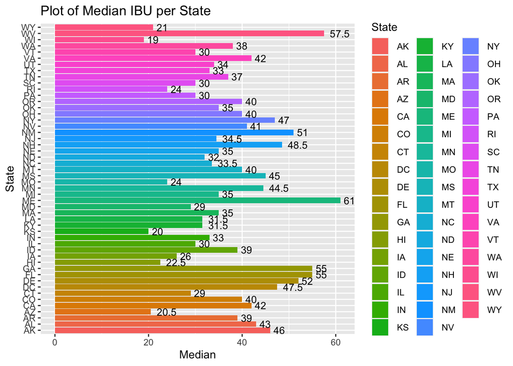

```r
#Chad's Code
#creating data sets that contain median IBU and ABV across the states
StateIBUMedian <- CleanData %>% group_by(State) %>% summarise(Median=median(IBU))
StateABVMedian <- CleanData %>% group_by(State) %>% summarise(Median=median(ABV))

#Plotting the median information using GGPlot2
IBUPlot = ggplot(StateIBUMedian, aes(x = State, y = Median, fill = State)) + geom_bar(stat = "identity", width = .9) + ggtitle("Plot of Median IBU per State") + geom_text(aes(label=Median),vjust=0.5, hjust=-.3 ,size=3.5) + coord_flip()
IBUPlot
```

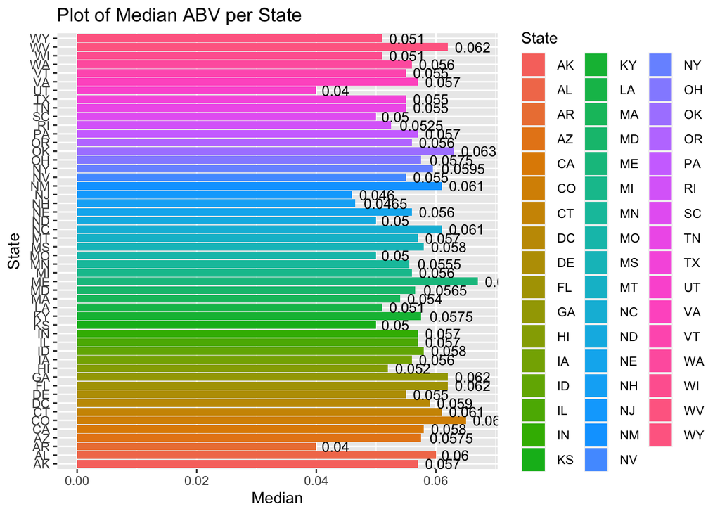

```r
ABVPlot = ggplot(StateABVMedian, aes(x = State, y = Median, fill = State)) + geom_bar(stat = "identity") + coord_flip() + ggtitle("Plot of Median ABV per State") + geom_text(aes(label=Median),vjust=0.5, hjust=-.2 ,size=3.5)
ABVPlot
```

```r
#Brittany's Code
#creating data sets that contain median IBU and ABV across the states
#ABV_IBU_State_Data=cbind(numeric_columns,BB_Merged$State)
#count(ABV_IBU_State_Data, BB_Merged$State)
#Num_State = cbind(numeric_columns,BB_Merged$State)
#This is the numeric columns plus the state column
#Median_ABV = aggregate(Num_State$ABV~BB_Merged$State, data=Num_State, FUN=function(Num_State) c(median=median(Num_State), count=length(Num_State)))
#Median_ABV = aggregate(Num_State$ABV~BB_Merged$State, data=Num_State, FUN=function(Num_State) c(median=median(Num_State), count=length(Num_State)))
#Num_State %>% group_by(BB_Merged$State) %>% summarise(median_IBU = median(IBU))
#var=Num_State %>% group_by(BB_Merged$State) %>% summarise(median_IBU = median(IBU))

#Plotting the median information using GGPlot2
#ggplot(data=var,aes(x=var$`BB_Merged$State`,y=var$median_IBU,fill=var$`BB_Merged$State`))+geom_histogram(stat="identity")+theme(axis.text.x=element_text(angle = 90,vjust = 0.5, hjust = 1))+labs(title="Median IBU by State",x= "State",y="Count of Median")
#Med_ABV=Num_State %>% group_by(BB_Merged$State) %>% summarise(Median_ABV = median(ABV))

#ggplot(data=var,aes(x=var$`BB_Merged$State`,y=Med_ABV$Median_ABV,fill=var$`BB_Merged$State`)) + geom_histogram(stat="identity") + theme(axis.text.x=element_text(angle = 90,vjust = 0.5, hjust = 1)) + labs(title="Median ABV by State",x= "State",y="Count of Median") + geom_text(aes(label=Med_ABV$Median_ABV),vjust=1.6,size=3.5)
```

We can see that Maine has the highest median IBU as well as the highest median ABV. There also seems to be a disparity between median IBU across all states where as all states seem to have similar median ABV values.

# Question 5

## The code below uses the summarise function combined with the group_by function to create a dataframe of all max values per state. The which.max function is then used as an index to the row with the max value overall. The final result is then displayed for both IBU and ABV

```r
#Chad's Code
#Max IBU
StateIBU <- CleanData %>% group_by(State) %>% summarise(Max_IBU = max(IBU))
StateIBU[which.max(StateIBU$Max_IBU),]
```

```
## # A tibble: 1 × 2
##   State Max_IBU
##   <chr>   <int>
## 1 " OR"     138
```

```r
#Max ABV
StateABV <- CleanData %>% group_by(State) %>% summarise(Max_ABV = max(ABV), Mean= mean(ABV))
StateABV[which.max(StateABV$Max_ABV),]
```

```
## # A tibble: 1 × 3
##   State Max_ABV   Mean
##   <chr>   <dbl>  <dbl>
## 1 " KY"   0.125 0.0646
```

```r
StateABV
```

```
## # A tibble: 50 × 3
##    State Max_ABV   Mean
##    <chr>   <dbl>  <dbl>
##  1 " AK"   0.065 0.0562
##  2 " AL"   0.093 0.0622
##  3 " AR"   0.04  0.04
##  4 " AZ"   0.095 0.0610
##  5 " CA"   0.099 0.0629
##  6 " CO"   0.099 0.0648
##  7 " CT"   0.088 0.0638
##  8 " DC"   0.092 0.065
##  9 " DE"   0.055 0.055
## 10 " FL"   0.082 0.0628
## # … with 40 more rows
```

```r
#Brittany's Code
#Finding Max ABV
#max_ABV = Num_State %>% group_by(BB_Merged$State) %>%summarise(max_ABV = max(ABV))
#max(max_ABV$max_ABV)
#which(max_ABV$max_ABV==0.125)
#max_ABV = data.frame(max_ABV)
#max_ABV[18,]

#Finding Max IBU
#max_IBU = Num_State %>% group_by(BB_Merged$State) %>% summarise(max_IBU = max(IBU))
#max(max_IBU$max_IBU)
#which(max_IBU$max_IBU==138)
#max_IBU = data.frame(max_IBU)
#max_IBU[38,]
```

The highest ABV across all states lies in Kentucky at 12.5%, and the highest IBU across all states lies in Oregon at 138 IBU.

# Question 6

## The code below uses the summary function to list out the statistical values. We then use GGPlot2 to plot a histogram of the ABV as well as a box plot of the ABV

```r
#Chad's Code
#Displaying the statistical data in a table
summary(CleanData$ABV)
```

```
##    Min. 1st Qu.  Median    Mean 3rd Qu.    Max.
## 0.02700 0.05000 0.05700 0.05991 0.06800 0.12500
```

```r
#Brittany's Code
#Displaying the statistical data in a table
summary(BB_Merged$ABV)
```

```
##    Min. 1st Qu.  Median    Mean 3rd Qu.    Max.
## 0.02700 0.05000 0.05700 0.05991 0.06800 0.12500
```

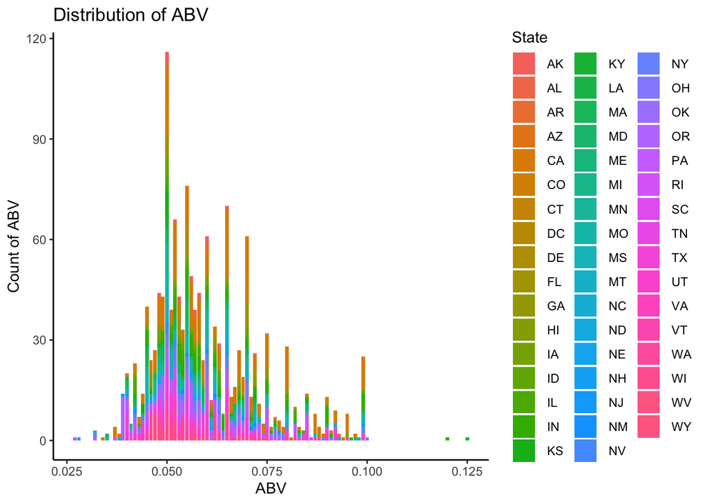

```r
#Using a histogram to display the ABV
ggplot(data=BB_Merged,aes(x=ABV,fill=State)) + geom_histogram(stat="count") + theme_classic() + labs(title="Distribution of ABV", x="ABV", y="Count of ABV")
```

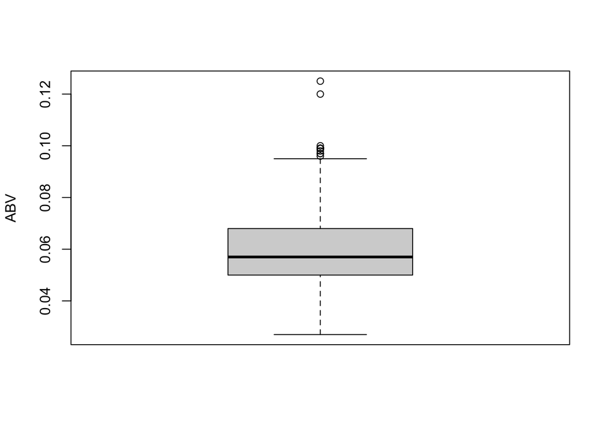

```r
#Displaying ABV in a box plot
boxplot(BB_Merged$ABV,ylab="ABV")
```

The histogram presents a positive skewness. This means that although the median ABV is 5.7%, the mean ABV slightly higher at almost 6%. From this we can infer that the general audience will be more inclined to purchase a higher ABV beer when available.

# Question 7

## The folowing code uses GGplot2 to plot the IBU vs ABV as a scatterplot using the geom_point function

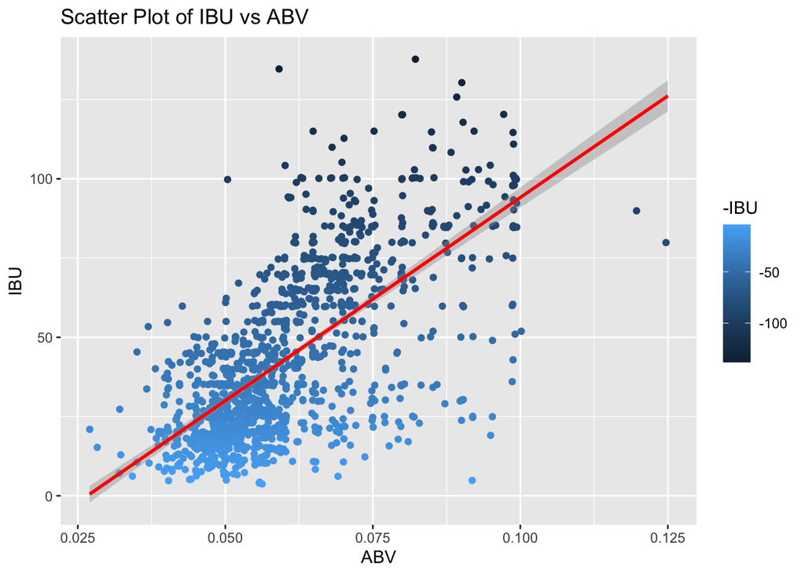

```r
#Creating a scatter plot and overlaying a computed line using the linear regression method
ggplot(CleanData, aes(x = ABV, y = IBU, color = -IBU)) + geom_point(position = "jitter") + geom_smooth(method = lm, color = "red") + ggtitle("Scatter Plot of IBU vs ABV")
```

From the Scatter Plot, we can see a positive correlation between ABV and IBU, however, due to the higher variance as ABV increases, we cannot say that the relationship between ABV and IBU follows a linear relationship.

# Question 8

## The following code filters the data to only display Ales and IPAs. From there, a new column is added to simplify classifications of the style. After that a KNN model is used to predict each entry as an ale or IPA based off of IBU and ABV only.

```r
# Setting the seed for replicability
set.seed(1)

# filtering the data to only display Ales and IPAs
Ales <- CleanData %>% filter(grepl('Ale', CleanData$Style) | grepl("IPA", CleanData$Style))

# writting a for loop to create a new binary column for classifying each row as either an Ale or an IPA
for (j in 1:length(Ales$Style))
{
  if (grepl("IPA", Ales$Style[j]) == TRUE)
  {
    Ales$IPA_Or_Ale[j] = "IPA"
  }
  else
  {
    Ales$IPA_Or_Ale[j] = "Ale"
  }
}
# transforming the new column into a factor
Ales$IPA_Or_Ale = as.factor(Ales$IPA_Or_Ale)

# Creating the test and training sets
trainIndices = sample(seq(1:length(Ales$Style)),round(.7*length(Ales$Style)))
trainIPA = Ales[trainIndices,]
testIPA = Ales[-trainIndices,]

# Creating and running the model
classifications = knn(trainIPA[,c(4,5)], testIPA[,c(4,5)], trainIPA$IPA_Or_Ale, k = 5)

# Displaying the results of the model as a confusion matrix
confusionMatrix(classifications, testIPA$IPA_Or_Ale)
```

```
## Confusion Matrix and Statistics
##
##           Reference
## Prediction Ale IPA
##        Ale 150  21
##        IPA  21  91
##
##                Accuracy : 0.8516
##                  95% CI : (0.8047, 0.8909)
##     No Information Rate : 0.6042
##     P-Value [Acc > NIR] : <2e-16
##
##                   Kappa : 0.6897
##
##  Mcnemar's Test P-Value : 1
##
##             Sensitivity : 0.8772
##             Specificity : 0.8125
##          Pos Pred Value : 0.8772
##          Neg Pred Value : 0.8125
##              Prevalence : 0.6042
##          Detection Rate : 0.5300
##    Detection Prevalence : 0.6042
##       Balanced Accuracy : 0.8448
##
##        'Positive' Class : Ale
##
```

# Question 9

```r
#NB Model using just ABV and IBU
two_variable_model = naiveBayes(IPA_Or_Ale~., data = Ales[,c(4,5,11)])
two_variable_predictions = predict(two_variable_model, testIPA)
Two_V_CM = confusionMatrix(two_variable_predictions, testIPA$IPA_Or_Ale)
Two_V_CM
```

```
## Confusion Matrix and Statistics
##
##           Reference
## Prediction Ale IPA
##        Ale 149  17
##        IPA  22  95
##
##                Accuracy : 0.8622
##                  95% CI : (0.8165, 0.9001)
##     No Information Rate : 0.6042
##     P-Value [Acc > NIR] : <2e-16
##
##                   Kappa : 0.7141
##
##  Mcnemar's Test P-Value : 0.5218
##
##             Sensitivity : 0.8713
##             Specificity : 0.8482
##          Pos Pred Value : 0.8976
##          Neg Pred Value : 0.8120
##              Prevalence : 0.6042
##          Detection Rate : 0.5265
##    Detection Prevalence : 0.5866
##       Balanced Accuracy : 0.8598
##
##        'Positive' Class : Ale
##
```

```r
#NB Model using Name, ABV, IBU, City, and State
five_variable_model = naiveBayes(IPA_Or_Ale~., data = Ales[,c(2,4,5,9,10,11)])
five_variable_predictions = predict(five_variable_model, testIPA)
Five_V_CM = confusionMatrix(five_variable_predictions, testIPA$IPA_Or_Ale)
Five_V_CM
```

```
## Confusion Matrix and Statistics
##
##           Reference
## Prediction Ale IPA
##        Ale 157   8
##        IPA  14 104
##
##                Accuracy : 0.9223
##                  95% CI : (0.8847, 0.9506)
##     No Information Rate : 0.6042
##     P-Value [Acc > NIR] : <2e-16
##
##                   Kappa : 0.8389
##
##  Mcnemar's Test P-Value : 0.2864
##
##             Sensitivity : 0.9181
##             Specificity : 0.9286
##          Pos Pred Value : 0.9515
##          Neg Pred Value : 0.8814
##              Prevalence : 0.6042
##          Detection Rate : 0.5548
##    Detection Prevalence : 0.5830
##       Balanced Accuracy : 0.9234
##
##        'Positive' Class : Ale
##
```